# Ekonometria Projekt

Daniel Kłodowski, Jan Kawalerski, Mikołaj Kita

2026-04-16

# Projekt: Analiza Rynku Nieruchomości na podstawie danych GUS

## 1. Wczytanie i przygotowanie danych

Na początku ładujemy potrzebne pakiety i wczytujemy nasz zbiór z GUS. Sprawdzamy również podstawowe podsumowanie wczytanych danych.

```r
library(tidyverse)
data<-read.csv2("DaneGUS.csv")
data <- data %>%
  relocate(Cenam2, .after = last_col())
summary(data)
```

```
##       Kod             Nazwa             Bezrobocie     Wynagrodzenia
##  Min.   : 201000   Length:380         Min.   : 1.000   Length:380
##  1st Qu.:1004750   Class :character   1st Qu.: 4.400   Class :character
##  Median :1636000   Mode  :character   Median : 6.350   Mode  :character
##  Mean   :1720679                      Mean   : 7.264
##  3rd Qu.:2475250                      3rd Qu.: 9.600
##  Max.   :3263000                      Max.   :24.600
##   Ludnosckm2         Firmy1000os       Cenam2
##  Length:380         Min.   : 2.20   Length:380
##  Class :character   1st Qu.: 4.60   Class :character
##  Mode  :character   Median : 5.60   Mode  :character
##                     Mean   : 5.94
##                     3rd Qu.: 6.50
##                     Max.   :17.60
```

Zauważamy, że dane liczbowe zostały wczytane jako tekst ze względu na polskie formatowanie. Używamy pętli, aby oczyścić kolumny od trzeciej do ostatniej

```r
for(i in 3:ncol(data)) {
  data[, i] <- gsub("\\s+", "", data[, i])
  data[, i] <- gsub(",", ".", data[, i])
  data[, i] <- as.numeric(data[, i])
}
```

Powyższa pętla kolejno usuwa spacje w tysiącach, zamienia polskie przecinki na kropki dziesiętne i wymusza konwersję na typ numeryczny.

## 2. Analiza rozkładów

Rozpoczynamy od wyodrębnienia wyłącznie zmiennych numerycznych, aby móc na nich prowadzić dalszą analizę statystyczną.

```r
dane_numeryczne <- data[, 3:ncol(data)]
```

Następnie badamy rozkład naszej zmiennej objaśnianej, generując jej histogram.

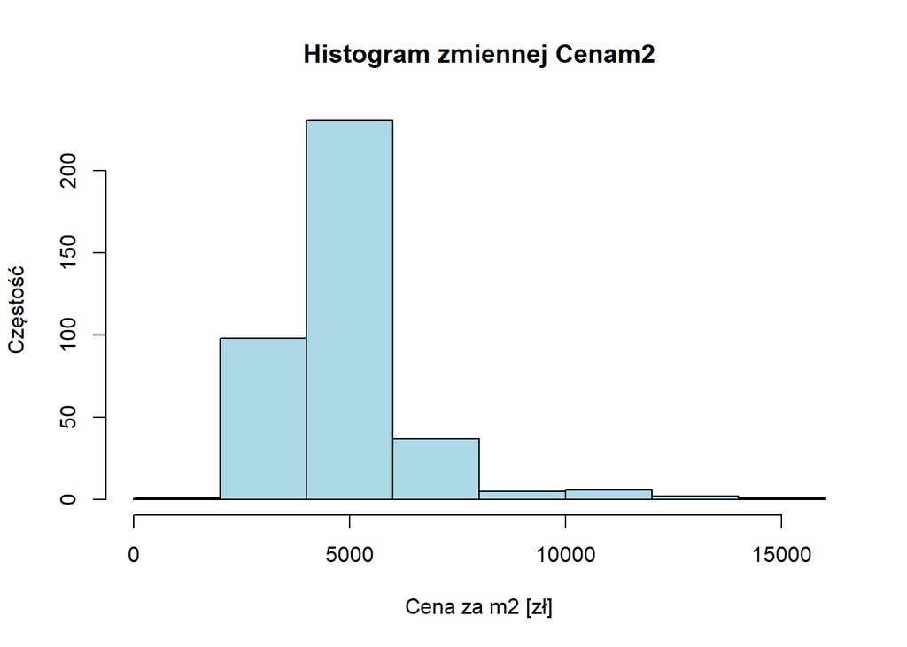

```r
hist(data$Cenam2,
     main = "Histogram zmiennej Cenam2",
     xlab = "Cena za m2 [zł]",
     ylab = "Częstość",
     col = "lightblue")
```

Wykres ten obrazuje rozkład empiryczny cen mieszkań. Aby dodatkowo sprawdzić obecność potencjalnych wartości odstających, rysujemy wykres pudełkowy.

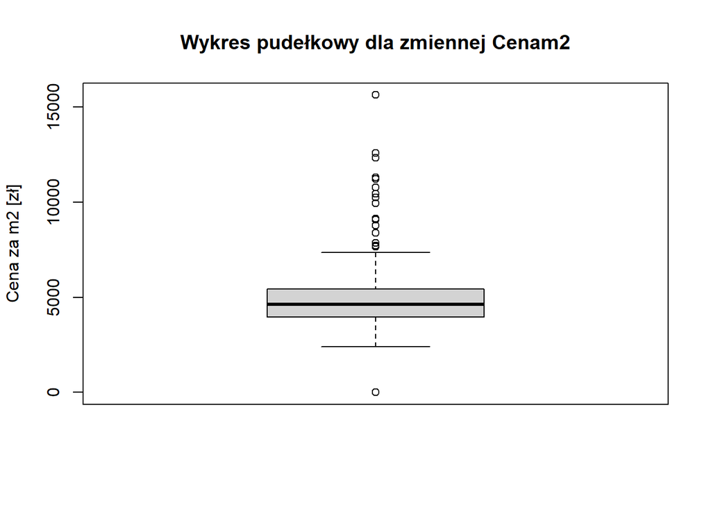

```r
boxplot(data$Cenam2,
        main = "Wykres pudełkowy dla zmiennej Cenam2",
        ylab = "Cena za m2 [zł]")
```

Pojedyncze kropki powyżej wąsów na wykresie pudełkowym wskazują na obecność bardzo drogich powiatów (najpewniej największych aglomeracji), które znacznie odbiegają od średniej rynkowej.

Poniżej zostały sprawdzone potencjalne nieprawidłowe wartości w danych.

```r
summary(dane_numeryczne)
```

```
##    Bezrobocie     Wynagrodzenia     Ludnosckm2       Firmy1000os
##  Min.   : 1.000   Min.   :    0   Min.   :  18.20   Min.   : 2.20
##  1st Qu.: 4.400   1st Qu.: 5407   1st Qu.:  57.85   1st Qu.: 4.60
##  Median : 6.350   Median : 5666   Median :  89.80   Median : 5.60
##  Mean   : 7.264   Mean   : 5803   Mean   : 355.42   Mean   : 5.94
##  3rd Qu.: 9.600   3rd Qu.: 6027   3rd Qu.: 180.07   3rd Qu.: 6.50
##  Max.   :24.600   Max.   :11362   Max.   :3600.10   Max.   :17.60
##      Cenam2
##  Min.   :    0
##  1st Qu.: 3975
##  Median : 4626
##  Mean   : 4874
##  3rd Qu.: 5412
##  Max.   :15633
```

Widzimy, że zdarzają się wartości 0 w kolumnach takich jak wynagrodzenia lub cena. Oznacza to jednak brak danych, niż rzeczywista obserwacja tej zmiennej. Obserwacje z niemożliwymi wartościami zostały więc usunięte.

```r
data <- data[!apply(data[c("Wynagrodzenia", "Cenam2")] <= 0, 1, any), ]
dane_numeryczne <- data[, 3:ncol(data)]
```

obliczamy macierz korelacji liniowej Pearsona.

```r
macierz_korelacji <- cor(dane_numeryczne)
```

Dla lepszej czytelności wizualizujemy te wyniki w formie graficznej przy użyciu odpowiedniego pakietu.

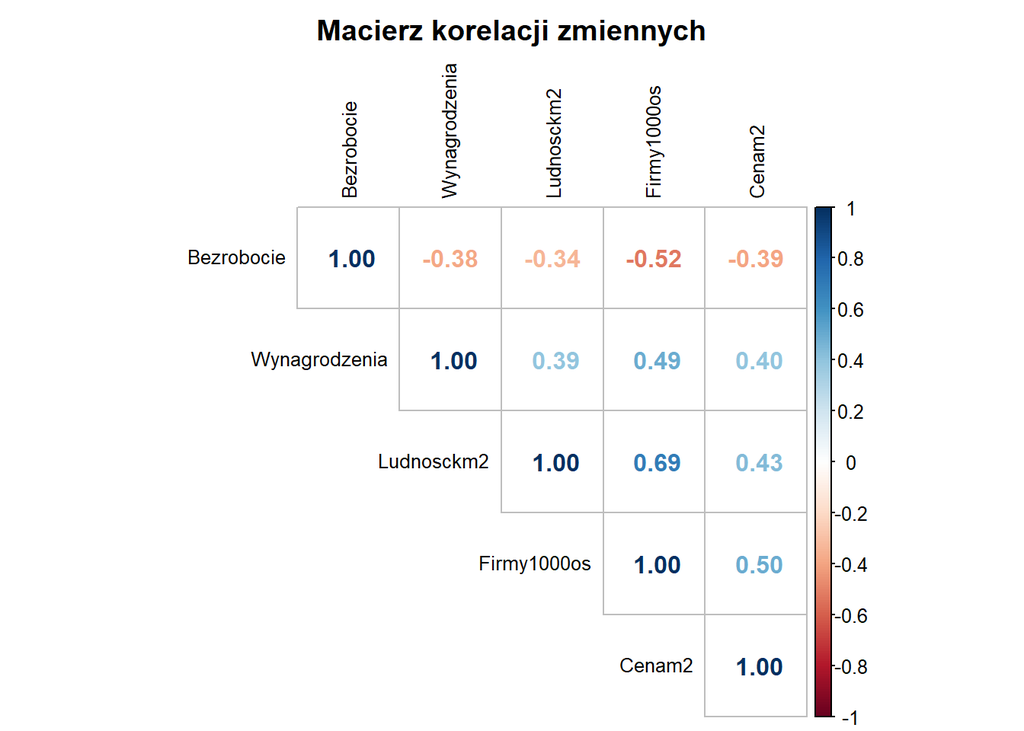

```r
library(corrplot)

corrplot(macierz_korelacji,
         method = "number",
         type = "upper",
         tl.col = "black",
         tl.cex = 0.8,
         title = "Macierz korelacji zmiennych",
         mar = c(0,0,2,0))
```

## Wnioski z eksploracji danych

Z powyższej macierzy wynika, że cena za m² najsilniej dodatnio koreluje z liczbą firm (r=0.50), gęstością zaludnienia (0.43) i wynagrodzeniami (0.40), a ujemnie z bezrobociem (-0.39). Widać również silną zależność (0.69) między gęstością zaludnienia a liczbą firm.

## 4. Podział na zbiór treningowy i testowy

Dzielimy nasz zbiór danych na dwie części: treningową oraz testową. Zbiór treningowy (70% obserwacji) posłuży nam do estymacji parametrów modelu, natomiast zbiór testowy (pozostałe 30%) wykorzystamy w późniejszych etapach do oceny jakości prognoz ex post. Ustawiamy ziarno losowości, aby nasz podział był powtarzalny przy każdym uruchomieniu skryptu

```r
set.seed(123)
train <- data %>% slice_sample(prop = 0.7)
test <- data %>% anti_join(train, by = "Kod")

train <- train[, 3:ncol(train)]
test <- test[, 3:ncol(test)]
```

## 5. Dobór zmiennych i estymacja modelu wstępnego

Naszym celem jest zbudowanie modelu objaśniającego kształtowanie się cen nieruchomości. Jako zmienną objaśnianą (Y) przyjmujemy cenę za metr kwadratowy (Cenam2). W pierwszym etapie estymujemy pełny model, uwzględniając wszystkie dostępne zmienne numeryczne jako potencjalne zmienne objaśniające.

Estymacji parametrów dokonujemy Klasyczną Metodą Najmniejszych Kwadratów z wykorzystaniem wyłącznie zbioru treningowego.

```r
model <- lm(Cenam2 ~ Bezrobocie + Wynagrodzenia + Ludnosckm2 + Firmy1000os, data = train)
summary(model)
```

```
##
## Call:
## lm(formula = Cenam2 ~ Bezrobocie + Wynagrodzenia + Ludnosckm2 +
##     Firmy1000os, data = train)
##
## Residuals:
##     Min      1Q  Median      3Q     Max
## -2457.8  -713.4  -193.1   463.8  6970.2
##
## Coefficients:
##                Estimate Std. Error t value Pr(>|t|)
## (Intercept)   1361.6197   852.7642   1.597  0.11155
## Bezrobocie     -42.9480    23.6533  -1.816  0.07057 .
## Wynagrodzenia    0.4116     0.1306   3.152  0.00182 **
## Ludnosckm2       0.5955     0.2012   2.959  0.00337 **
## Firmy1000os    206.7401    62.4441   3.311  0.00106 **
## ---
## Signif. codes:  0 '***' 0.001 '**' 0.01 '*' 0.05 '.' 0.1 ' ' 1
##
## Residual standard error: 1320 on 259 degrees of freedom
## Multiple R-squared:  0.3954, Adjusted R-squared:  0.3861
## F-statistic: 42.35 on 4 and 259 DF,  p-value: < 2.2e-16
```

Zgodnie z zasadą ceteris paribus, otrzymane parametry oznaczają, że:

-Bezrobocie: wzrost o 1 p.p. obniża cenę metra kwadratowego średnio o ok. 43 zł.

-Wynagrodzenia: wzrost średniej pensji o 1 zł podnosi cenę za m2 o ok. 0,41 zł.

-Gęstość zaludnienia: każda dodatkowa osoba na km² to wzrost ceny o ok. 0,60 zł.

-Firmy: jedna dodatkowa firma na 1000 mieszkańców podbija cenę za m2 średnio o ok. 207 zł.

## 6. Diagnostyka i poprawa modelu

Poniżej została zastosowana metoda Hellwiga, w celu znaleznienia kombinacji zmienncych objaśniających, niosących największą wartość informacyjną.

```r
corre = cor(train)
R0 <- corre["Cenam2", colnames(corre) != "Cenam2"] # korelacje zmiennych objaśniających z objaśnianą
R <- corre[colnames(corre) != "Cenam2", colnames(corre) != "Cenam2"] # korelacje pomiędzy zmiennymi objaśniającymi

comb <- expand.grid(rep(list(c(T,F)), 4)) # wszystkie kombinacje

hellwig <- function(idx){
  if(sum(idx) == 0) return(0)

  selected <- which(idx)

  H <- 0 # pojemność integralna kombinacji nośników informacji

  for(i in selected){
    denom <- 0 # suma korelacji pomiędzy zmiennymi objaśniającymi
    # w danej kombinacji

    for(j in selected){
      denom <- denom + abs(R[i,j])
    }

    hi <- (R0[i]^2) / denom # indywidualna pojemność nośnika informacji
    H <- H + hi
  }

  return(H)
}

H_values <- apply(comb, 1, hellwig)

best_comb_index <- which.max(H_values)
best_combination_numbers <- which(comb[best_comb_index, ] == 1)

# wyniki
H_values[best_comb_index]
```

```
## [1] 0.3893975
```

```r
colnames(train)[colnames(train) != "Cenam2"][best_combination_numbers]
```

```
## [1] "Bezrobocie"    "Wynagrodzenia" "Ludnosckm2"    "Firmy1000os"
```

Wynik potwierdza, że należy użyć wszystkich zmiennych w modelu.

### Liniowość modelu

Założyliśmy, że wszystkie zależności między zmienną objaśnianą a objaśniającymi są liniowe. Musimy jednak sprawdzić, czy rzeczywiście tak jest.

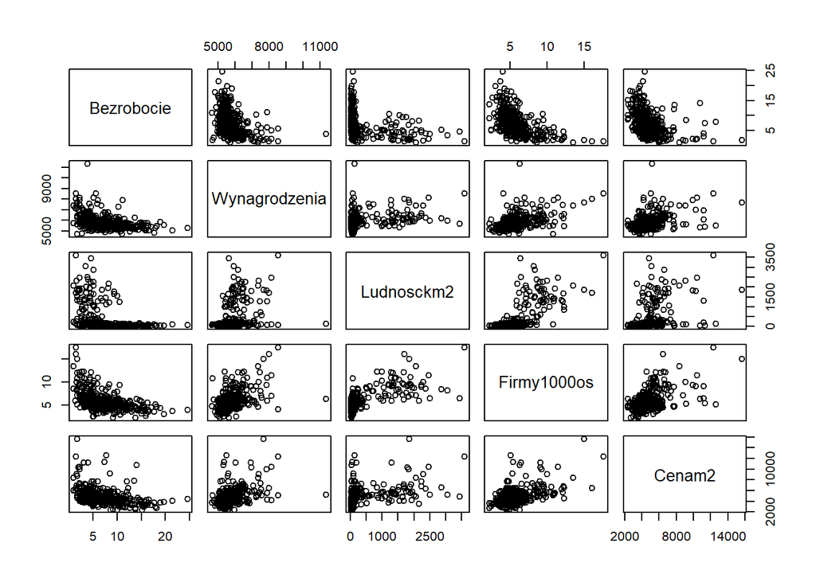

```r
pairs(dane_numeryczne)
```

W przypadku pary cena-firmy zależność kształtuje się na podobną do liniowej, jednak w przypadku pozostałych zmiennych nie jest już ona tak oczywista.

W kolejnym kroku należy przetestować inne postacie zależności. W tym celu zastosowano test Ramsey’a (RESET), polegający na rozszerzeniu modelu o dodatkowe zmienne w postaci potęg wartości dopasowanych przez pierwotny model (tu: drugiego i trzeciego stopnia).  
H0 - model jest poprawne wyspecyfikowany

```r
library(lmtest)
resettest(model, power = 2:3, type = "fitted")
```

```
##
##  RESET test
##
## data:  model
## RESET = 7.5573, df1 = 2, df2 = 257, p-value = 0.0006468
```

Na poziomie istotności 5% odrzucamy hipotezę zerową testu RESET, co wskazuje na niepoprawną specyfikację modelu. Może to oznaczać pominięcie istotnych zmiennych lub niewłaściwą postać funkcyjną (np. brak nieliniowości).

Przeprowadzono również test RESET w wersji z dodaniem potęg zmiennych objaśniających.

```r
resettest(model, type = "regressor", power = 2:3)
```

```
##
##  RESET test
##
## data:  model
## RESET = 1.6285, df1 = 8, df2 = 251, p-value = 0.117
```

Wynik testu nie wskazuje na istotność tych składników, co sugeruje, że ewentualna niepoprawna specyfikacja modelu nie wynika z prostych nieliniowości w postaci kwadratów (lub sześcianów) zmiennych.  
Mimo istotności pierwszego testu RESET, zdecydowano się pozostawić pierwotną postać modelu ze względu na jego prostotę i interpretowalność.

### Współliniowość zmiennych objaśniających

W celu sprawdzania, czy zmienne objaśniające są współliniowe, posłużono się metodą VIF (Variance Inflation Factor). Ma ona pokazać, jak bardzo zwiększa się wariancja w związku z ich skorelowaniem.

```r
model <- lm(Cenam2 ~ Bezrobocie + Wynagrodzenia + Ludnosckm2 + Firmy1000os, data = train)

library(car)
vif(model)
```

```
##    Bezrobocie Wynagrodzenia    Ludnosckm2   Firmy1000os
##      1.448952      1.367331      2.380322      2.848572
```

Wszystkie mniejsze niż 5, więc nie są wyraźnie współliniowe.

Poniżej sprawdzono także losowość reszt, za pomocą testu serii.  
H0 - reszty są losowe

```r
r = model$residuals
library(randtests)
runs.test(r)
```

```
##
##  Runs Test
##
## data:  r
## statistic = -1.7266, runs = 119, n1 = 132, n2 = 132, n = 264, p-value =
## 0.08425
## alternative hypothesis: nonrandomness
```

Nie odrzucono hipotezy zerowej na poziomie istotności 5%, co oznacza, że reszty są losowe.

## Interakcje między zmiennymi

Poniżej sprawdzono, czy istnieją interakcje wśród zmiennych objaśniających, czyli czy wpłych jednej zmiennej na objaśnianą zależy od poziomu innej zmiennej.

```r
model_i <- lm(Cenam2 ~ Bezrobocie*Wynagrodzenia + Ludnosckm2 + Firmy1000os, data = train)
summary(model_i)$adj.r.squared
```

```
## [1] 0.4204442
```

```r
model_i <- lm(Cenam2 ~ Bezrobocie + Wynagrodzenia*Ludnosckm2 + Firmy1000os, data = train)
summary(model_i)$adj.r.squared
```

```
## [1] 0.435496
```

```r
model_i <- lm(Cenam2 ~ Bezrobocie + Wynagrodzenia + Ludnosckm2*Firmy1000os, data = train)
summary(model_i)$adj.r.squared
```

```
## [1] 0.4060395
```

Najlepej dodasowany model wydaje się być z interakcją między wynagrodzeniami a ludnością.

```r
model_i <- lm(Cenam2 ~ Bezrobocie + Wynagrodzenia*Ludnosckm2 + Firmy1000os, data = train)
summary(model_i)
```

```
##
## Call:
## lm(formula = Cenam2 ~ Bezrobocie + Wynagrodzenia * Ludnosckm2 +
##     Firmy1000os, data = train)
##
## Residuals:
##     Min      1Q  Median      3Q     Max
## -3125.2  -689.6  -159.6   416.8  6770.4
##
## Coefficients:
##                            Estimate Std. Error t value Pr(>|t|)
## (Intercept)               3.570e+03  9.353e+02   3.817 0.000169 ***
## Bezrobocie               -5.990e+01  2.295e+01  -2.610 0.009570 **
## Wynagrodzenia             1.177e-01  1.390e-01   0.847 0.397948
## Ludnosckm2               -3.721e+00  9.080e-01  -4.098 5.58e-05 ***
## Firmy1000os               1.446e+02  6.122e+01   2.363 0.018890 *
## Wynagrodzenia:Ludnosckm2  6.734e-04  1.384e-04   4.865 1.99e-06 ***
## ---
## Signif. codes:  0 '***' 0.001 '**' 0.01 '*' 0.05 '.' 0.1 ' ' 1
##
## Residual standard error: 1266 on 258 degrees of freedom
## Multiple R-squared:  0.4462, Adjusted R-squared:  0.4355
## F-statistic: 41.58 on 5 and 258 DF,  p-value: < 2.2e-16
```

Spada błąd standardowy i zwiększa się statystyka R kwadrat. Dodatkowo, interakcja ta jest istotna na poziomie 0,1%.  
Zastosowano test ANOVA w celu weryfikacji poprawy modelu, po dodaniu interakcji.  
H0 - interakcja nie poprawia modelu

```r
anova(model, model_i)
```

```
## Analysis of Variance Table
##
## Model 1: Cenam2 ~ Bezrobocie + Wynagrodzenia + Ludnosckm2 + Firmy1000os
## Model 2: Cenam2 ~ Bezrobocie + Wynagrodzenia * Ludnosckm2 + Firmy1000os
##   Res.Df       RSS Df Sum of Sq      F    Pr(>F)
## 1    259 451584823
## 2    258 413634338  1  37950485 23.671 1.991e-06 ***
## ---
## Signif. codes:  0 '***' 0.001 '**' 0.01 '*' 0.05 '.' 0.1 ' ' 1
```

Test potwierdza, że model z interakcją między zmiennymi Wynagrodzenia i Ludnosckm2 jest istotnie lepszy od modelu bez tej interakcji na poziomie 0,1%.

```r
model <- model_i
r <- model$residuals
```

Interpretacja tej interakcji prezentuje się następująco: wraz ze wzrostem gęstości zaludnienia, wpływ wynagrodzeń na cenę mieszkań staje się silniejszy. Każdy dodatkowy 1 mieszkaniec/km² zwiększa ten efekt o około 0.0007 zł.

### Normalność rozkładu reszt

Normalność rozkładu reszt jest istotna dla poprawności wnioskowania o istotności parametrów.  
W celu zweryfikowania tego warunku, został użyty test Shapiro-Wilka.  
H0 - dane mają rozkład normalny

```r
shapiro.test(r)
```

```
##
##  Shapiro-Wilk normality test
##
## data:  r
## W = 0.81242, p-value < 2.2e-16
```

Test wykazał, że rozkład reszt nie jest normalny.

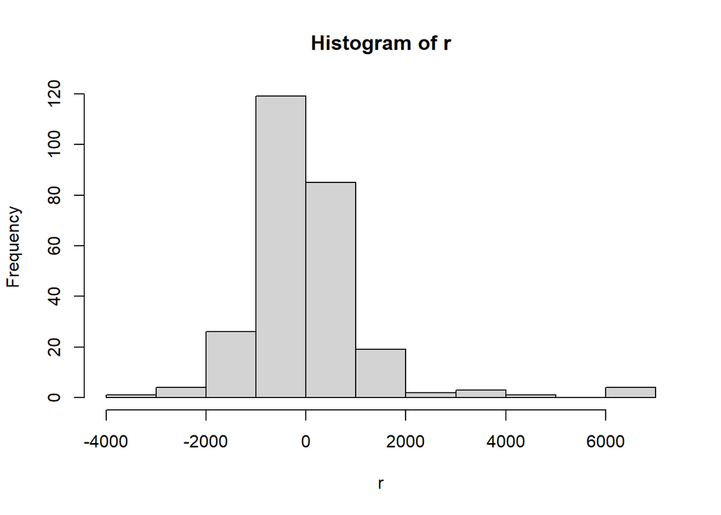

```r
hist(r)
```

Prawostronna skośność rozkładu reszt sugeruje, że w danych występują obserwacje, dla których wartości rzeczywiste są istotnie wyższe od wartości przewidywanych przez model.  
Brak normalności rozkładu może zniekształcać wnioskowanie stystyczne, np. wynik testu F istotności modelu. Należy jednak zauważyć, że próba jest duża, co niweluje ten problem.

### Homoskedastyczność

Kolejną ważną właściwością jest homoskedastyczność - stałość wariancji - będąca założeniem metody najmniejszych kwadratów.

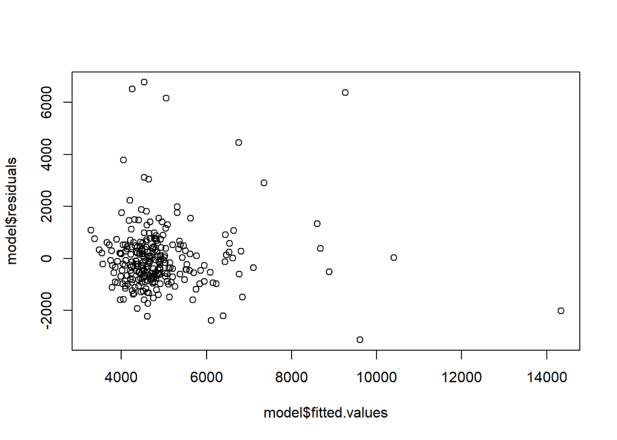

```r
plot(model$fitted.values, model$residuals)
```

Do weryfikacji został użyty test White’a, który sprawdza, czy kwadraty reszt zależą liniowo lub nieliniowo od poziomu przewidywanego wyniku (regresja).  
H0 - homoskedastyczność

```r
train$y_dop = model$fitted.values
bptest(model, ~y_dop + I(y_dop^2) + I(y_dop^3), data = train)
```

```
##
##  studentized Breusch-Pagan test
##
## data:  model
## BP = 11.742, df = 3, p-value = 0.00832
```

```r
train <- subset(train, select = -y_dop)
```

Test wykazał, że zachodzi istotna zależność na poziomie 5%. Wynika z tego, że nie jest spełniony warunek homoskedastyczności. Błędy szacunku, mogą być więc źle wyznaczone, a testy statystyczne zaburzone.

#### Wartości odstające

Co więcej, wykres reszt względem wartości dopasowanych nie wskazuje na wyraźną nieliniową strukturę zależności, co sugeruje, że liniowa postać modelu jest w dużym stopniu odpowiednia.  
Można zauważyć też, że występują wartości potencjalnie ekstremalne, na które metoda najmniejszych kwadratów jest bardzo wrażliwa. W tym przypadku jednak, nie zostaną usunięte, gdyż nie są one wynikiem błędu.

## 7. Analiza ex-post

W tej części sprawdzimy, jak nasz ostateczny model radzi sobie z przewidywaniem cen mieszkań na danych, których “nie widział” podczas estymacji (czyli na naszym zbiorze testowym). W tym celu wyznaczymy prognozy, a następnie obliczymy popularne miary błędów ex-post: Średni Błąd Bezwzględny (MAE), Pierwiastek Błędu Średniokwadratowego (RMSE) oraz Średni Absolutny Błąd Procentowy (MAPE).

```r
predykcje <- predict(model, newdata = test)
rzeczywiste <- test$Cenam2

bledy <- rzeczywiste - predykcje

# Miary błędów ex-post
MAE <- mean(abs(bledy))
RMSE <- sqrt(mean(bledy^2))
MAPE <- mean(abs(bledy / rzeczywiste)) * 100

# Wypisanie wyników
cat("Średni Błąd Bezwzględny (MAE):", round(MAE, 2), "zł\n")
```

```
## Średni Błąd Bezwzględny (MAE): 822.8 zł
```

```r
cat("Pierwiastek Błędu Średniokwadratowego (RMSE):", round(RMSE, 2), "zł\n")
```

```
## Pierwiastek Błędu Średniokwadratowego (RMSE): 1307.01 zł
```

```r
cat("Średni Absolutny Błąd Procentowy (MAPE):", round(MAPE, 2), "%\n")
```

```
## Średni Absolutny Błąd Procentowy (MAPE): 16.36 %
```

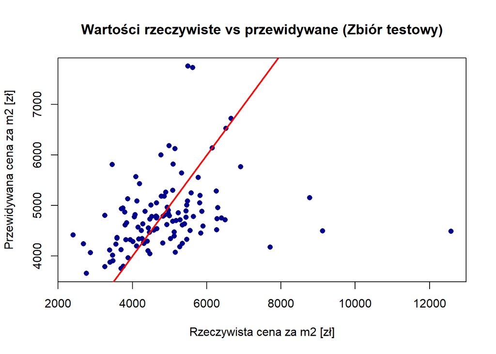

```r
plot(rzeczywiste, predykcje,
     main = "Wartości rzeczywiste vs przewidywane (Zbiór testowy)",
     xlab = "Rzeczywista cena za m2 [zł]",
     ylab = "Przewidywana cena za m2 [zł]",
     pch = 16, col = "darkblue")
abline(a = 0, b = 1, col = "red", lwd = 2) # Idealne dopasowanie (y = x)
```

### 7.1 Analiza wrażliwości

Aby sprawdzić odporność modelu na wartości odstające przeprowadzam eksperyment, usuwam najbardziej odstające powiaty.

```r
# Identyfikacja wartości odstających z wykresu pudełkowego (powyżej górnego wąsa)
wartosci_odstajace <- boxplot.stats(train$Cenam2)$out

# Stworzenie nowego zbioru treningowego bez wartości odstających
train_bez_odst <- train %>%
  filter(!Cenam2 %in% wartosci_odstajace)

# Estymacja ostatecznego modelu (z interakcją) na oczyszczonych danych
model_bez_odst <- lm(Cenam2 ~ Bezrobocie + Wynagrodzenia*Ludnosckm2 + Firmy1000os, data = train_bez_odst)

summary(model_bez_odst)
```

```
##
## Call:
## lm(formula = Cenam2 ~ Bezrobocie + Wynagrodzenia * Ludnosckm2 +
##     Firmy1000os, data = train_bez_odst)
##
## Residuals:
##      Min       1Q   Median       3Q      Max
## -2002.79  -564.73   -30.47   501.76  2374.25
##
## Coefficients:
##                            Estimate Std. Error t value Pr(>|t|)
## (Intercept)               3.273e+03  6.451e+02   5.074 7.74e-07 ***
## Bezrobocie               -6.749e+01  1.502e+01  -4.495 1.08e-05 ***
## Wynagrodzenia             2.085e-01  9.637e-02   2.164   0.0315 *
## Ludnosckm2                2.595e-02  1.218e+00   0.021   0.9830
## Firmy1000os               8.284e+01  4.111e+01   2.015   0.0450 *
## Wynagrodzenia:Ludnosckm2  6.596e-05  1.978e-04   0.334   0.7390
## ---
## Signif. codes:  0 '***' 0.001 '**' 0.01 '*' 0.05 '.' 0.1 ' ' 1
##
## Residual standard error: 809.6 on 243 degrees of freedom
## Multiple R-squared:  0.3621, Adjusted R-squared:  0.349
## F-statistic: 27.59 on 5 and 243 DF,  p-value: < 2.2e-16
```

Analiza błędów dla nowego modelu

```r
# Predykcja na zbiorze testowym przy użyciu nowego modelu
predykcje_bez_odst <- predict(model_bez_odst, newdata = test)
rzeczywiste <- test$Cenam2

# Obliczenie błędów
bledy_bez_odst <- rzeczywiste - predykcje_bez_odst

# Miary błędów ex-post
MAE_bez_odst <- mean(abs(bledy_bez_odst))
RMSE_bez_odst <- sqrt(mean(bledy_bez_odst^2))
MAPE_bez_odst <- mean(abs(bledy_bez_odst / rzeczywiste)) * 100

# Wypisanie wyników
cat("Błędy dla modelu bez wartości odstających:\n")
```

```
## Błędy dla modelu bez wartości odstających:
```

```r
cat("Średni Błąd Bezwzględny (MAE):", round(MAE_bez_odst, 2), "zł\n")
```

```
## Średni Błąd Bezwzględny (MAE): 802.57 zł
```

```r
cat("Pierwiastek Błędu Średniokwadratowego (RMSE):", round(RMSE_bez_odst, 2), "zł\n")
```

```
## Pierwiastek Błędu Średniokwadratowego (RMSE): 1291.56 zł
```

```r
cat("Średni Absolutny Błąd Procentowy (MAPE):", round(MAPE_bez_odst, 2), "%\n")
```

```
## Średni Absolutny Błąd Procentowy (MAPE): 15.51 %
```

Spadło R^2 i niektóre zmienne straciły istotność, zdawałoby się, że model się pogorszył. Mimo wszystko spadły miary błędów. W pierwotnym modelu interakcja Wynagrodzenia:Ludnosckm2 oraz sama gęstość zaludnienia były bardzo istotne, okazuje się jednak, że w przypadku typowych powiatów jednak to nie ma znaczenia.

### 7.2 Model z usuniętymi nieistotnymi zmiennymi

Wcześniejszy punkt dowodzi, że “efekt tłoku” wpływający na ceny mieszkań jest zjawiskiem charakterystycznym wyłącznie dla największych aglomeracji, a nie uniwersalnym prawem dla całego kraju.

```r
model_polska_lokalna <- lm(Cenam2 ~ Bezrobocie + Wynagrodzenia, data = train_bez_odst)
summary(model_polska_lokalna)
```

```
##
## Call:
## lm(formula = Cenam2 ~ Bezrobocie + Wynagrodzenia, data = train_bez_odst)
##
## Residuals:
##     Min      1Q  Median      3Q     Max
## -2006.1  -641.3   -26.1   497.6  2329.8
##
## Coefficients:
##                 Estimate Std. Error t value Pr(>|t|)
## (Intercept)   3375.25354  547.90618   6.160 2.94e-09 ***
## Bezrobocie     -97.58660   14.10758  -6.917 3.96e-11 ***
## Wynagrodzenia    0.33417    0.08694   3.844 0.000154 ***
## ---
## Signif. codes:  0 '***' 0.001 '**' 0.01 '*' 0.05 '.' 0.1 ' ' 1
##
## Residual standard error: 864.5 on 246 degrees of freedom
## Multiple R-squared:  0.2637, Adjusted R-squared:  0.2577
## F-statistic: 44.06 on 2 and 246 DF,  p-value: < 2.2e-16
```

```r
# Predykcja na zbiorze testowym przy użyciu modelu uproszczonego
predykcje_lokalne <- predict(model_polska_lokalna, newdata = test)

# Błędy ex-post
bledy_lokalne <- rzeczywiste - predykcje_lokalne
MAE_lokalny <- mean(abs(bledy_lokalne))
RMSE_lokalny <- sqrt(mean(bledy_lokalne^2))
MAPE_lokalny <- mean(abs(bledy_lokalne / rzeczywiste)) * 100

cat("Średni Błąd Bezwzględny (MAE):", round(MAE_lokalny, 2), "zł\n")
```

```
## Średni Błąd Bezwzględny (MAE): 760.69 zł
```

```r
cat("Pierwiastek Błędu Średniokwadratowego (RMSE):", round(RMSE_lokalny, 2), "zł\n")
```

```
## Pierwiastek Błędu Średniokwadratowego (RMSE): 1252.91 zł
```

```r
cat("Średni Absolutny Błąd Procentowy (MAPE):", round(MAPE_lokalny, 2), "%\n")
```

```
## Średni Absolutny Błąd Procentowy (MAPE): 14.79 %
```

## Interpretacja parametrów najlepszego modelu

W przypadku interakcji nie możemy interpretować zmiennych Wynagrodzenia i Ludnosckm2 w oderwaniu od siebie. Ich wpływ jest sumą efektu głównego i efektu interakcji. Wyniki z summary() oznaczają wpływ danej zmiennej na cenę, ale tylko w sytuacji, gdy ta druga zmienna wynosi zero.

## Podsumowanie

### 1. Cel i zakres prac

Przygotowanie danych: Przeprowadziliśmy czyszczenie zbioru danych GUS, konwertując formatowanie polskie na numeryczne i usuwając błędne obserwacje (np. zerowe wynagrodzenia).

Analiza statystyczna: Zbadaliśmy korelacje i rozkłady, identyfikując silny wpływ wynagrodzeń, gęstości zaludnienia i liczby firm na ceny mieszkań.

Modelowanie: Zbudowaliśmy model Klasycznej Metody Najmniejszych Kwadratów (KMNK) z uwzględnieniem interakcji między wynagrodzeniami a gęstością zaludnienia.

Weryfikacja ex-post: Przetestowaliśmy model na zbiorze testowym (30% danych) i przeprowadziliśmy analizę wrażliwości (Robustness Check), usuwając skrajne obserwacje (metropolie).

### 2. Główne „zwycięstwa”

Udowodniliśmy, że w dużych miastach wysoka gęstość zaludnienia potęguje wpływ wynagrodzeń na ceny mieszkań (synergia popytowa).

### 3. Problemy i wyzwania:

Rozkład reszt jest prawostronnie skośny przez bardzo drogie powiaty, co utrudnia klasyczne wnioskowanie statystyczne w pełnej próbie.

Dwubiegunowość rynku: Odkryliśmy, że jeden model nie jest w stanie idealnie opisać jednocześnie „Polski lokalnej” i wielkich aglomeracji – usunięcie odstających miast całkowicie zmieniło strukturę istotności zmiennych.

### 4. Dalsze kroki

Ekonometria przestrzenna: Uwzględnienie sąsiedztwa powiatów (ceny w powiatach podwarszawskich zależą od Warszawy).

Modele nieliniowe: Zastosowanie logarytmowania zmiennej objaśnianej, co mogłoby „naprawić” problem normalności reszt.

Segmentacja: Budowa dwóch osobnych modeli: jednego dla metropolii i drugiego dla pozostałych regionów.